# Making Locus Plots

2021-08-24

## Make Locus Plots

```r
library(ggbio)
library(GenomicRanges)
library(tidyverse)


gencode_plot <- function(genename, n = Inf){
  gff_loc <- gencode_gff[ gencode_gff$gene_name == genename]

  transcripts <- unique(gff_loc$transcript_id)
  transcripts <- transcripts[order(transcripts)]
  transcripts <- tail(transcripts, n)

  gff_loc <- gff_loc[ gff_loc$transcript_id %in% transcripts]

  #gff_split <- split(gff_loc, gff_loc$transcript_id)
  gff_loc <- gff_loc[ gff_loc$type %in% c("exon", "UTR")]
  ggplot() + geom_alignment( gff_loc, aes(group = transcript_id, fill = "GENCODE"), range.geom = "rect", gap.geom = "arrow")+
    theme_bw() + scale_fill_manual(values = "black") +
    labs(fill = "") #+ theme(legend.text = element_blank())
}


junction_plot <- function(gene, gwas, qtl, n = Inf, colourby = "PP.H4.abf", legend_pos = "right", min_coloc = 0.5){
  junctions_loc <- filter(all_coloc, QTL_Gene == gene, QTL == qtl, GWAS == gwas, PP.H4.abf > min_coloc) %>%
    tidyr::separate(QTL_junction, into = c("chr", "start", "end"), sep = ":|-", remove = FALSE ) %>%
    mutate(start = as.numeric(start), end = as.numeric(end)) %>%
    arrange(desc(PP.H4.abf)) %>%
    head(n)

  stopifnot(nrow(junctions_loc) > 0)

  ## Plot a bar
  grange_loc <-
    GRanges(seqnames = junctions_loc$chr,
            ranges = IRanges(start = junctions_loc$start, end = junctions_loc$end),
            PP.H4.abf = junctions_loc$PP.H4.abf,
            SNP = junctions_loc$QTL_SNP, junction_id = junctions_loc$QTL_junction#,
            #QTL_Beta = junctions_loc$QTL_Beta
            )


  grange_loc$junction_id <- factor(grange_loc$junction_id, levels = rev(junctions_loc$QTL_junction))

  plot <-
    ggplot() +
    geom_alignment(data = grange_loc, aes_string(group = "junction_id", fill = colourby), colour = NA, range.geom = "rect" ) +
    scale_fill_viridis_c(values = c(0,1)) + theme_bw() + theme(legend.position = legend_pos)

  return(plot)
}

snp_plot <- function(Gene, qtl, snp_width = 50, type = "GWAS", n = Inf, min_coloc = 0.5, rs = FALSE){
  if(type == "GWAS"){
  snp_loc <- filter(all_coloc, QTL_Gene == Gene, QTL == qtl) %>%
    dplyr::select(SNP = GWAS_SNP, chr = GWAS_chr, end = GWAS_pos, GWAS) %>%
    distinct() %>%
    mutate(label = paste0(GWAS, "\n", SNP) )

    #tidyr::separate(QTL_junction, into = c("chr", "start", "end"), sep = ":|-", remove = FALSE ) %>%
    #mutate(start = as.numeric(start), end = as.numeric(end)) %>%
    #arrange(desc(PP.H4.abf)) %>%
    #head(n)
  stopifnot(nrow(snp_loc) > 0)

  ## Plot a bar
  grange_loc <-
    GRanges(seqnames = snp_loc$chr,
            ranges = IRanges(start = snp_loc$end - snp_width, end = snp_loc$end),
            SNP = snp_loc$SNP, GWAS = snp_loc$GWAS, label = snp_loc$label )
  }
  if(type == "QTL"){
    snp_loc <- filter(all_coloc, QTL_Gene == Gene, QTL == qtl, PP.H4.abf >= min_coloc) %>%
      dplyr::select(SNP = QTL_SNP, chr = QTL_chr, end = QTL_pos, QTL_junction, PP.H4.abf) %>%
      distinct() %>%
    arrange(desc(PP.H4.abf)) %>%
    mutate(label = paste0(QTL_junction,"\n", SNP) )
    #tidyr::separate(QTL_junction, into = c("chr", "start", "end"), sep = ":|-", remove = FALSE ) %>%
    #mutate(start = as.numeric(start), end = as.numeric(end)) %>%
    #arrange(desc(PP.H4.abf)) %>%
    #head(n)
    # only keep RS ID SNPs
    if(rs == TRUE){
      snp_loc <- snp_loc %>%
        filter(grepl("rs", SNP ) )
    }
    # if only want top n SNPs
    snp_loc <- snp_loc %>%  head(n)

    stopifnot(nrow(snp_loc) > 0)

    ## Plot a bar
    grange_loc <-
      GRanges(seqnames = snp_loc$chr,
              ranges = IRanges(start = snp_loc$end - snp_width, end = snp_loc$end),
              SNP = snp_loc$SNP, label = snp_loc$label )
    grange_loc$label <- factor(grange_loc$label, levels = rev(snp_loc$label))

  }

  #grange_loc$junction_id <- factor(grange_loc$junction_id, levels = rev(junctions_loc$QTL_junction))

  plot <-
    ggplot() +
    geom_alignment(data = grange_loc, aes(group = label, fill = "test"), range.geom = "rect" ) +
    theme_bw() + scale_fill_manual(values = "black") +
    theme(legend.text = element_blank() ) + labs(fill = "")
    #scale_fill_viridis_c() + theme_bw() #+# theme(legend.position = "top")

  return(plot)
}

all_coloc <- read_tsv(here::here("data/QTLs/Nov_2020/results/COLOC/all_COLOC_results_merged_H4_0_no_LD.tsv.gz"))

all_coloc <- filter(all_coloc, GWAS == "NicolasSuggestive_2018")

#all_coloc <- read_tsv(here::here("data/COLOC/Nicolas_suggestive/all_COLOC_results_merged_H4_0_no_LD.tsv.gz"))

all_coloc$GWAS <- "Nicolas_2018"

coloc_hit_genes <- filter(all_coloc, PP.H4.abf > 0.5) %>% pull(QTL_Gene)

gencode_coloc <- here::here("ALS_SC/gencode_for_coloc_hits.RData")
if( !file.exists(gencode_coloc)){

  gencode_gff <- rtracklayer::import("~/GENCODE/gencode.v30.annotation.gtf.gz")
  gencode_gff <- gencode_gff[ gencode_gff$gene_name %in% coloc_hit_genes ]
  save(gencode_gff, file = gencode_coloc )
}else{
  load(gencode_coloc)
}
```

```r
process_vcf <- function(vcf, ID = NA){
  if( !is.na(ID) ){
      vcf$ID <- ID
    }
  out <- vcf %>%
    select(-CHROM, -POS,-REF, -ALT, -QUAL, -FILTER, -INFO, -FORMAT) %>%
    tidyr::gather(key = "sample", value = "genotype", -ID) %>%
    mutate(genotype = str_split_fixed(genotype, ":", 2)[,1] ) %>%
    mutate(genotype_binary =
             case_when(genotype == "0/0" ~ 0,
                       genotype == "0/1" ~ 1,
                      genotype == "1/1" ~ 2 ),
           sample = gsub("\\.", "-", sample)
    )
  return(out)
}

process_junctions <- function(junction_bed, gene){
  sqtl_loc <- junction_bed #%>%
    #filter(gid == gene)

  junction_ids <- str_split_fixed(sqtl_loc$ID, ":", 5)[,c(1,2,3)]
  sqtl_loc$junction_id <- apply(junction_ids, MAR = 1, FUN = function(x) { paste0(x[1], ":", x[2], "-", x[3])} )

  sqtl_loc %>%
    select(-Chr, -start, -end, -gid, -strand, -ID ) %>%
    tidyr::gather(key = "sample", value = "junction_ratio", -junction_id)
}
```

## ATXN3

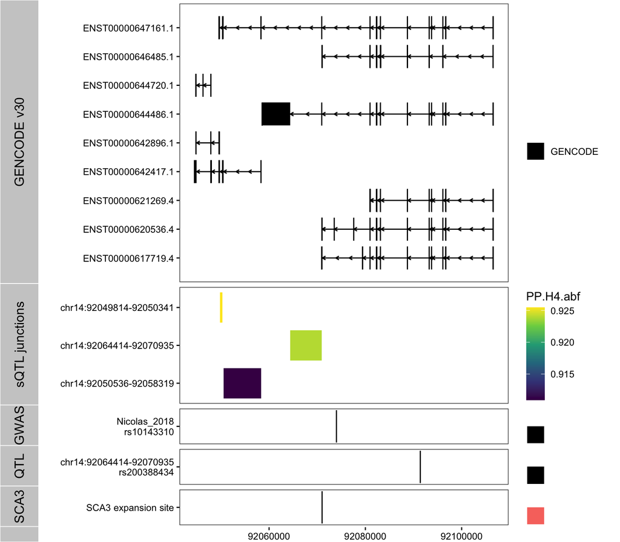

```r
atxn3_gencode <- gencode_plot("ATXN3", 10)


atxn3_junctions <- junction_plot(gene = "ATXN3", gwas = "Nicolas_2018", qtl = "NYGC_Lumbar_sQTL", n = 3 )

#tracks("GENCODE v30" = atxn3_gencode, "sQTL junctions" = atxn3_junctions, heights = c(4,1))

qtl_snps <- snp_plot(Gene = "ATXN3", qtl = "NYGC_Lumbar_sQTL", type = "QTL", min_coloc = 0.8, n = 1, rs = TRUE)

gwas_snps <- snp_plot(Gene = "ATXN3", qtl = "NYGC_Lumbar_sQTL", type = "GWAS")

## POLYQ EXPANSION - hg38 chr14:92071010-92071011
expansion_gr <- GRanges(seqnames = "chr14", ranges = IRanges(start = 92071010, end = 92071011), label = "SCA3 expansion site")

expansion_plot <-
  ggplot() +
    geom_alignment(data = expansion_gr, aes(group = label, fill = ""), range.geom = "rect" ) + theme_bw() +
  labs(fill = "")

atxn3_plot <- tracks("GENCODE v30" = atxn3_gencode, "sQTL junctions" = atxn3_junctions,
       "GWAS" = gwas_snps,
       "QTL" = qtl_snps,
       "SCA3" = expansion_plot,
       heights = c(7,3,1,1,1),
  xlim = c(92044496,92106625 )
) +
  theme(panel.grid = element_blank(), axis.text = element_text(colour = "black"), axis.ticks = element_line(colour = "black") )

ggsave(atxn3_plot,filename =  here::here("ALS_SC/plots/ATXN3_multiplot.pdf"), width = 8, height = 5 )


atxn3_plot
```

## C9orf72

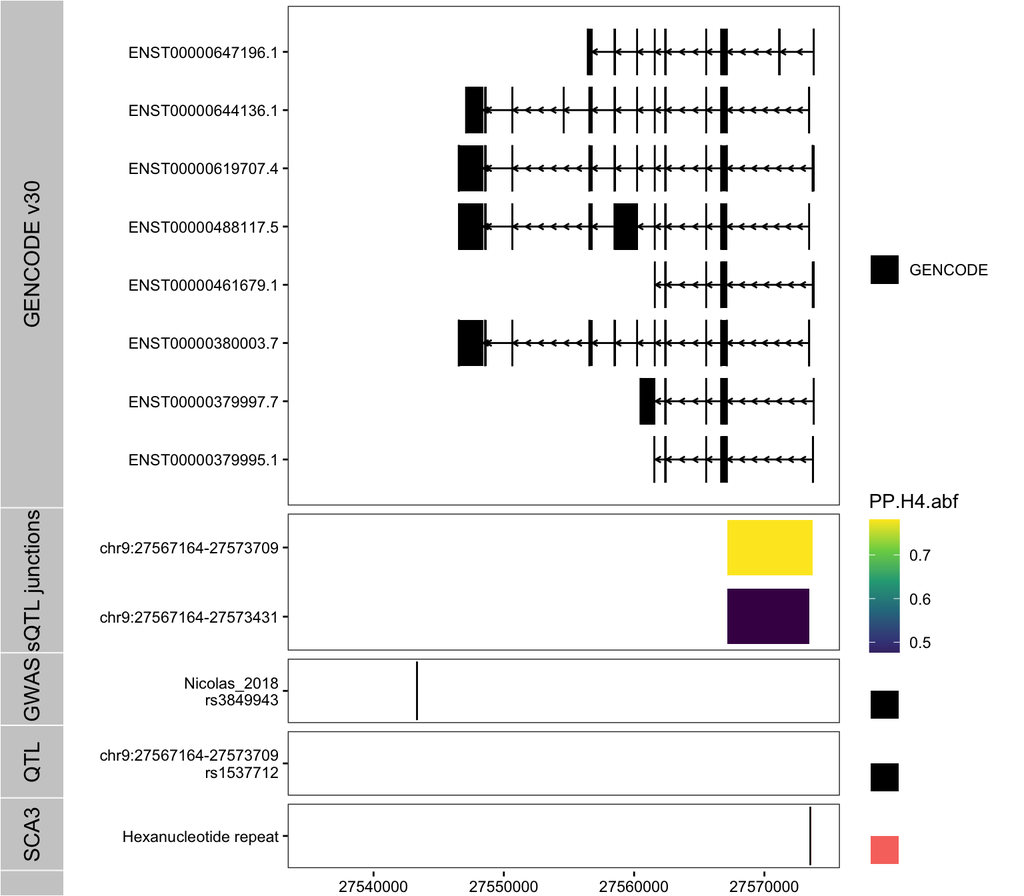

```r
c9_gencode <- gencode_plot("C9orf72", 10)

c9_junctions <- junction_plot(gene = "C9orf72", gwas = "Nicolas_2018", qtl = "NYGC_Lumbar_sQTL", min_coloc = 0, n = 2 )

#tracks("GENCODE v30" = c9_gencode, "sQTL junctions" = c9_junctions, heights = c(4,1))

qtl_snps <- snp_plot(Gene = "C9orf72", qtl = "NYGC_Lumbar_sQTL", type = "QTL", min_coloc = 0.7, n = 1, rs = TRUE)

gwas_snps <- snp_plot(Gene = "C9orf72", qtl = "NYGC_Lumbar_sQTL", type = "GWAS")

# find C9 HRE region
# chr9:27573528-27573546 (thanks Expansion Hunter!)
expansion_gr <- GRanges(seqnames = "chr9", ranges = IRanges(start = 27573528, end = 27573546), label = "Hexanucleotide repeat")


expansion_plot <-
  ggplot() +
    geom_alignment(data = expansion_gr, aes(group = label, fill = ""), range.geom = "rect" ) + theme_bw() +
  labs(fill = "")

c9_plot <- tracks("GENCODE v30" = c9_gencode,
                  "sQTL junctions" = c9_junctions,
       "GWAS" = gwas_snps,
       "QTL" = qtl_snps,
       "SCA3" = expansion_plot,
       heights = c(7,2,1,1,1),
  xlim = c(27535340,27573866 )
) +
  theme(panel.grid = element_blank(), axis.text = element_text(colour = "black"), axis.ticks = element_line(colour = "black") )


c9_plot
```

```r
ggsave(c9_plot,filename =  here::here("ALS_SC/plots/C9orf72_multiplot.pdf"), width = 8, height = 5 )
```

# FNBP1

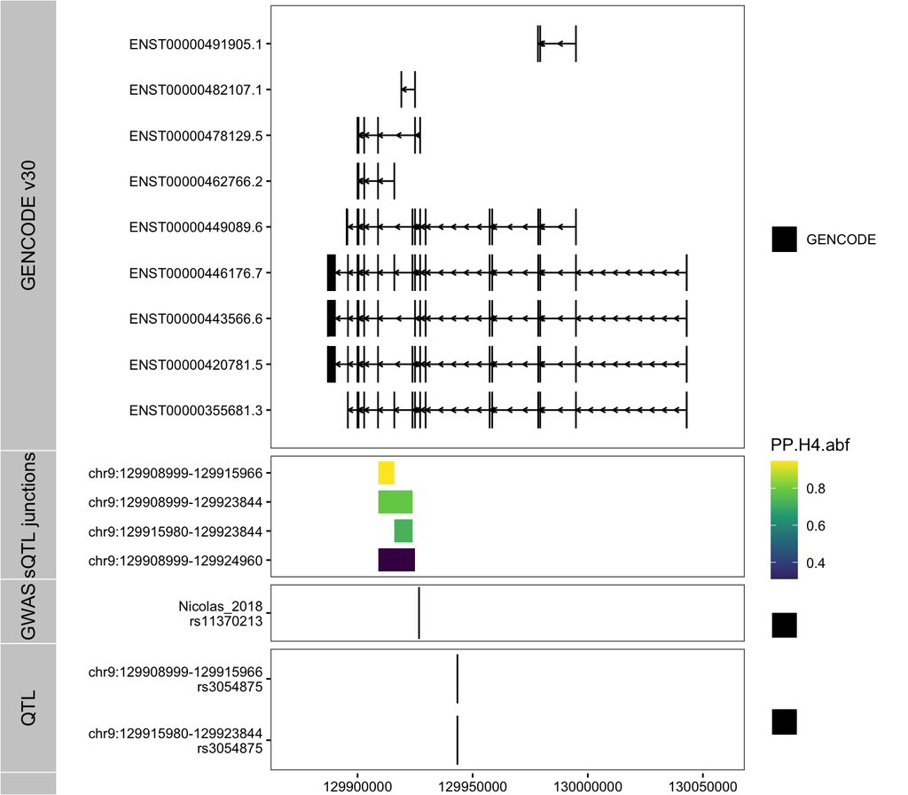

```r
fnbp1_gencode <- gencode_plot("FNBP1", Inf)

fnbp1_junctions <- junction_plot(gene = "FNBP1", gwas = "Nicolas_2018", qtl = "NYGC_Lumbar_sQTL", min_coloc = 0.1)

#tracks("GENCODE v30" = fnbp1_gencode, "sQTL junctions" = fnbp1_junctions, heights = c(4,1))

qtl_snps <- snp_plot(Gene = "FNBP1", qtl = "NYGC_Lumbar_sQTL", type = "QTL", min_coloc = 0.1, rs = TRUE)

gwas_snps <- snp_plot(Gene = "FNBP1", qtl = "NYGC_Lumbar_sQTL", type = "GWAS")


fnbp1_plot <- tracks("GENCODE v30" = fnbp1_gencode,
                  "sQTL junctions" = fnbp1_junctions,
       "GWAS" = gwas_snps,
       "QTL" = qtl_snps,
       heights = c(7,2,1,2)
) +
  theme(panel.grid = element_blank(), axis.text = element_text(colour = "black"), axis.ticks = element_line(colour = "black") )


fnbp1_meta <- filter(all_coloc, QTL_Gene == "FNBP1", GWAS == "Nicolas_2018", QTL == "NYGC_Lumbar_sQTL")


fnbp1_plot
```

FNBP1 is a sQTL, clearly a cassette exon. GTEx labels it exon 12. This exon sQTL turns up in GTEX (esophagus, colon) but not in brain. A different sQTL which I don’t detect futher upstream. Is inclusion of this exon cell-type specific? Plan: Correlate exon usage with deconvolved proportions. If it’s a cell-type specific effect there should be an association.

# Compare FNBP1 QTL with cell proportions

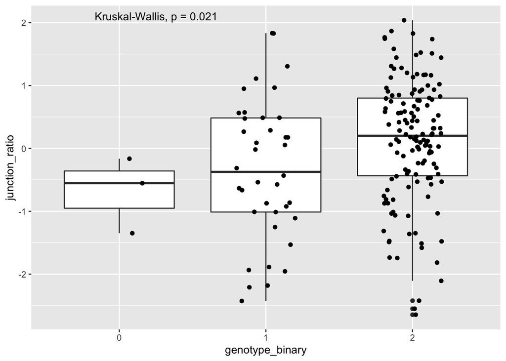

```r
mathys_music_resid <- read_tsv(here::here("data/deconvolution/Mathys_MuSiC_residual_results.tsv"))
sample_key <- read_tsv( here::here("ALS_SC/FNBP1/LumbarSpinalCord_sample_key.txt"))

deconv_df <- mathys_music_resid  %>%
  select(sample_id = sample, cell, deconv) %>%
  pivot_wider(names_from = cell,values_from = deconv )  %>%
  left_join(sample_key) %>%
  select(sample = participant_id, -sample_id, everything() ) %>%
  drop_na()




sqtl_junctions <- read_tsv( here::here("ALS_SC/FNBP1/CSC_FNBP1_splicing.txt") )  %>%
    select(-`#Chr`, -start, -end, -ID ) %>%
    tidyr::gather(key = "sample", value = "junction_ratio")

fnbp_genotypes <- process_vcf(vcf = read.table(here::here("ALS_SC/FNBP1/FNBP1_rs11370213.vcf"), header=TRUE), ID = "rs11370213" )

covariates <- read_tsv(here::here("ALS_SC/FNBP1/LumbarSpinalCord_splicing_peer15.gene.combined_covariates.txt")) %>%
  pivot_longer(names_to = "sample", values_to = "value", cols = !ID) %>%
  pivot_wider( names_from = "ID",values_from = "value" )



fnbp1_lm <- inner_join(sqtl_junctions, covariates) %>%
  column_to_rownames(var = "sample")

#summary( lm(junction_ratio ~ genotype_binary, fnbp1_lm) )
fnbp1_resid <- resid( lm(junction_ratio ~ ., fnbp1_lm) )

fnbp1_all <- fnbp1_lm %>%
  rownames_to_column(var = "sample") %>%
  mutate(genotype_binary = fnbp_genotypes$genotype_binary[match(.$sample, fnbp_genotypes$sample)]) %>%
  mutate( junction_resid = fnbp1_resid) %>%
  left_join(deconv_df, by = "sample")


fnbp1_all %>%
  mutate(genotype_binary = factor(genotype_binary)) %>%
  ggplot(aes(x = genotype_binary, y = junction_ratio)) + geom_boxplot(aes(group = genotype_binary)) +
  geom_jitter(width = 0.2, height = 0) +
  ggpubr::stat_compare_means()
```

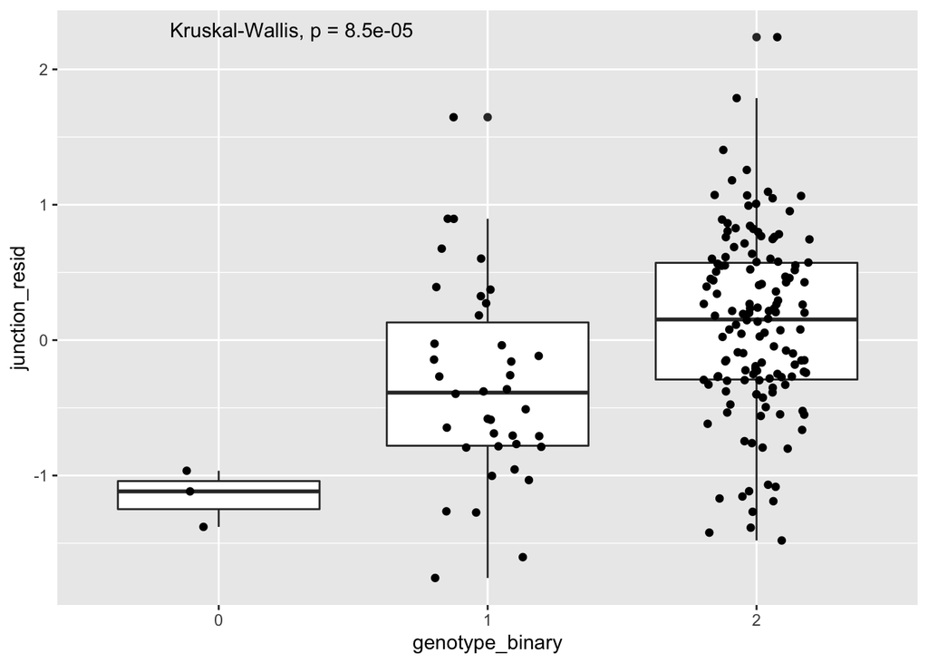

```r
fnbp1_all %>%
  mutate(genotype_binary = factor(genotype_binary)) %>%
  ggplot(aes(x = genotype_binary, y = junction_resid)) + geom_boxplot(aes(group = genotype_binary)) +
  geom_jitter(width = 0.2, height = 0) +
  ggpubr::stat_compare_means()
```

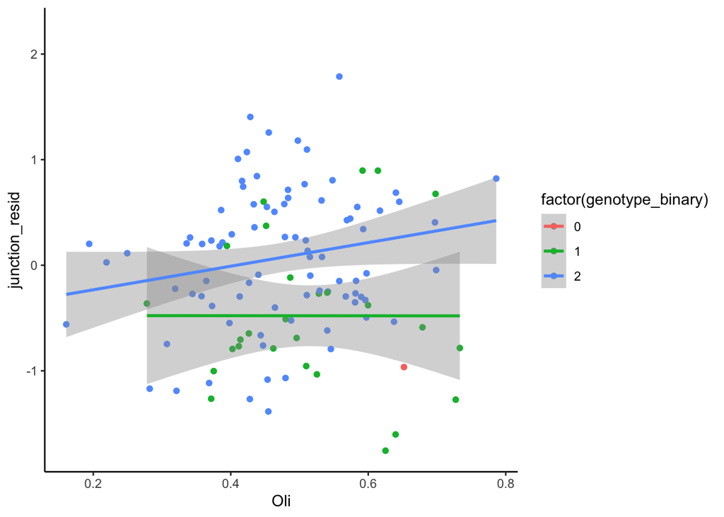

```r
fnbp1_all %>%
  ggplot(aes(x = Oli, y = junction_resid, colour = factor(genotype_binary) )) + geom_point() +
  geom_smooth(method = "lm") + theme_classic()
```

```r
summary(lm( junction_resid ~ genotype_binary + Oli + Ast + Mic + End + Per + Ex,  fnbp1_all ))
```

```
##
## Call:
## lm(formula = junction_resid ~ genotype_binary + Oli + Ast + Mic +
##     End + Per + Ex, data = fnbp1_all)
##
## Residuals:
##      Min       1Q   Median       3Q      Max
## -1.54182 -0.44603 -0.02447  0.45210  1.60061
##
## Coefficients:
##                   Estimate Std. Error t value Pr(>|t|)
## (Intercept)      1037.1020   687.2382   1.509    0.134
## genotype_binary     0.5874     0.1396   4.206 5.48e-05 ***
## Oli             -1037.9273   687.2301  -1.510    0.134
## Ast             -1038.2448   687.2575  -1.511    0.134
## Mic             -1039.9807   687.4368  -1.513    0.133
## End             -1035.1853   686.9735  -1.507    0.135
## Per             -1041.3814   687.2181  -1.515    0.133
## Ex              -1058.2985   691.3527  -1.531    0.129
## ---
## Signif. codes:  0 '***' 0.001 '**' 0.01 '*' 0.05 '.' 0.1 ' ' 1
##
## Residual standard error: 0.659 on 105 degrees of freedom
##   (66 observations deleted due to missingness)
## Multiple R-squared:  0.1853, Adjusted R-squared:  0.131
## F-statistic: 3.411 on 7 and 105 DF,  p-value: 0.002524
```

## NFASC

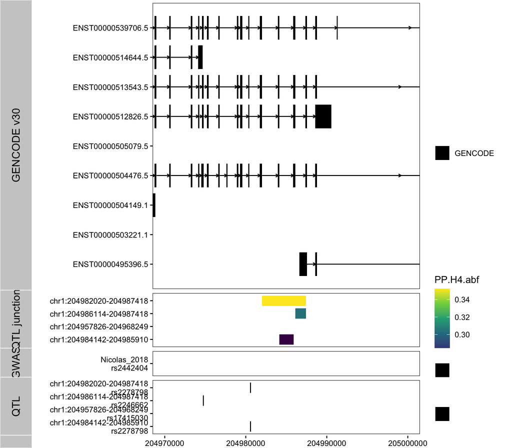

```r
nfasc_gencode <- gencode_plot("NFASC", 10)

nfasc_junctions <- junction_plot(gene = "NFASC", gwas = "Nicolas_2018", qtl = "NYGC_Cervical_sQTL", min_coloc = 0.2)

#tracks("GENCODE v30" = nfasc_gencode, "sQTL junctions" = nfasc_junctions, heights = c(4,1))

qtl_snps <- snp_plot(Gene = "NFASC", qtl = "NYGC_Cervical_sQTL", type = "QTL", min_coloc = 0.2, rs = FALSE)

gwas_snps <- snp_plot(Gene = "NFASC", qtl = "NYGC_Cervical_sQTL", type = "GWAS")


nfasc_plot <- tracks("GENCODE v30" = nfasc_gencode,
                  "sQTL junctions" = nfasc_junctions,
       "GWAS" = gwas_snps,
       "QTL" = qtl_snps,
       heights = c(10,2,1,2),
       xlim = c(204970000, 205000000)
) +
  theme(panel.grid = element_blank(), axis.text = element_text(colour = "black"), axis.ticks = element_line(colour = "black") )


nfasc_plot
```

## GGNBP2

An eQTL

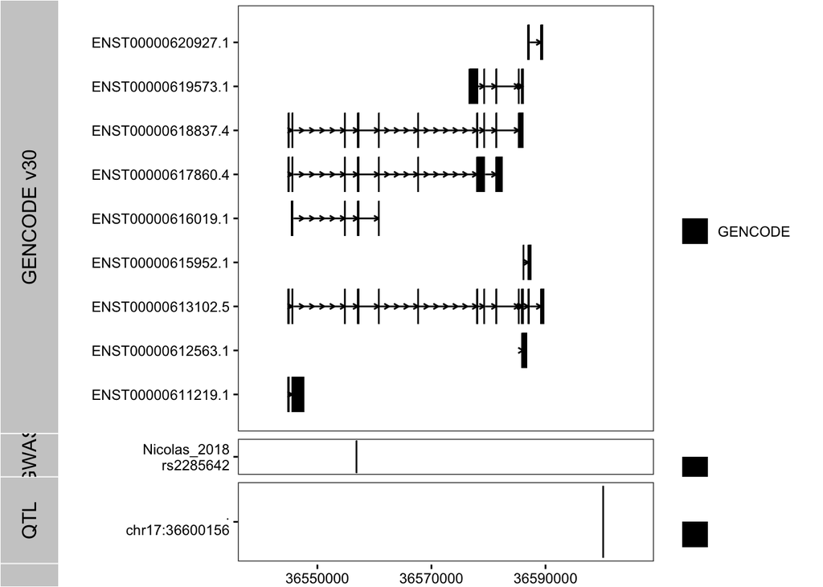

```r
ggnbp2_gencode <- gencode_plot("GGNBP2", 10)

#ggnbp2_junctions <- junction_plot(gene = "GGNBP2", gwas = "Nicolas_2018", qtl = "NYGC_Cervical_eQTL", min_coloc = 0.2)

#tracks("GENCODE v30" = ggnbp2_gencode, "sQTL junctions" = ggnbp2_junctions, heights = c(4,1))

qtl_snps <- snp_plot(Gene = "GGNBP2", qtl = "NYGC_Cervical_eQTL", type = "QTL", min_coloc = 0.2, rs = FALSE)

gwas_snps <- snp_plot(Gene = "GGNBP2", qtl = "NYGC_Cervical_eQTL", type = "GWAS")


ggnbp2_plot <- tracks("GENCODE v30" = ggnbp2_gencode,
                 # "sQTL junctions" = ggnbp2_junctions,
       "GWAS" = gwas_snps,
       "QTL" = qtl_snps,
       heights = c(10,1,2)
) +
  theme(panel.grid = element_blank(), axis.text = element_text(colour = "black"), axis.ticks = element_line(colour = "black") )


ggnbp2_plot
```

## ACSL5

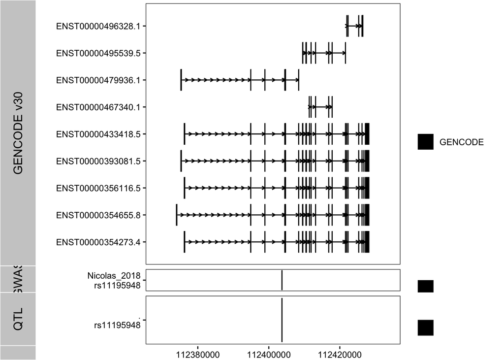

```r
ACSL5_gencode <- gencode_plot("ACSL5", 10)

#ACSL5_junctions <- junction_plot(gene = "ACSL5", gwas = "Nicolas_2018", qtl = "NYGC_Cervical_eQTL", min_coloc = 0.2)

#tracks("GENCODE v30" = ACSL5_gencode, "sQTL junctions" = ACSL5_junctions, heights = c(4,1))

qtl_snps <- snp_plot(Gene = "ACSL5", qtl = "NYGC_Cervical_eQTL", type = "QTL", min_coloc = 0.2, rs = FALSE)

gwas_snps <- snp_plot(Gene = "ACSL5", qtl = "NYGC_Cervical_eQTL", type = "GWAS")


ACSL5_plot <- tracks("GENCODE v30" = ACSL5_gencode,
                 # "sQTL junctions" = ACSL5_junctions,
       "GWAS" = gwas_snps,
       "QTL" = qtl_snps,
       heights = c(10,1,2)
) +
  theme(panel.grid = element_blank(), axis.text = element_text(colour = "black"), axis.ticks = element_line(colour = "black") )


ACSL5_plot
```

ACSL5 is nice - lead GWAS SNP is lead QTL SNP.

Nott data suggests only expressed in microglia - no ChIP or ATAC from any other cell type. However, none of the Microglia QTL data shows colocalisation.